# ОТЧЕТ О ВЫПОЛНЕНИИ ЛАБОРАТОРНОЙ РАБОТЫ №2

*дисциплина: Основы информационной безопасности*

Лихтенштейн Алина Алексеевна

# Цель работы

Целью данной работы является получение практических навыков работы в консоли с атрибутами файлов, закрепление теоретических основ дискреционного разграничения доступа в современных системах с открытым кодом на базе ОС Linuх.

# Выполнение лабораторной работы

В установленной при выполнении предыдущей лабораторной работы операционной системе создадим учётную запись пользователя guest (использую учётную запись администратора) и зададим ей пароль:

Создадим учетную запись guest и зададим ей пароль (рис. [-@fig:001])

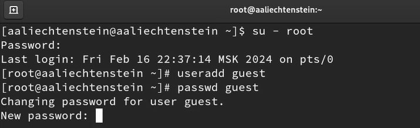

cоздание учетной записи guest и установка пароля

Определим директорию, в которой мы находитесь, командой pwd. Сравним её с приглашением командной строки. Определим, является ли она нашей домашней директорией? Если нет, зайдем в домашнюю директорию.

Определим директорию командой pwd. (рис. [-@fig:002])

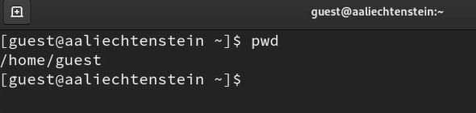

команда pwd

Уточнение имени пользователя командой whoami. Использование команд id и groups.

Использование команд whoami, id и groups. (рис. [-@fig:003])

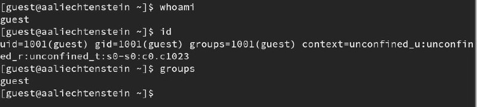

команды whoami, id и groups

Использование команды cat /etc/passwd. (рис. [-@fig:004])

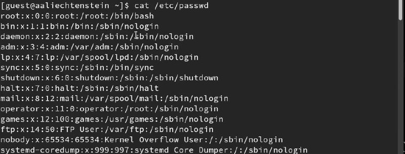

команда cat /etc/passwd

Создадим в домашней директории поддиректорию dir1 командой mkdir dir1.

Использование команды mkdir dir1. (рис. [-@fig:005])

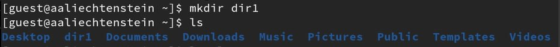

команда mkdir dir1

Использование команд ls -l, lsattr и chmod. (рис. [-@fig:006])

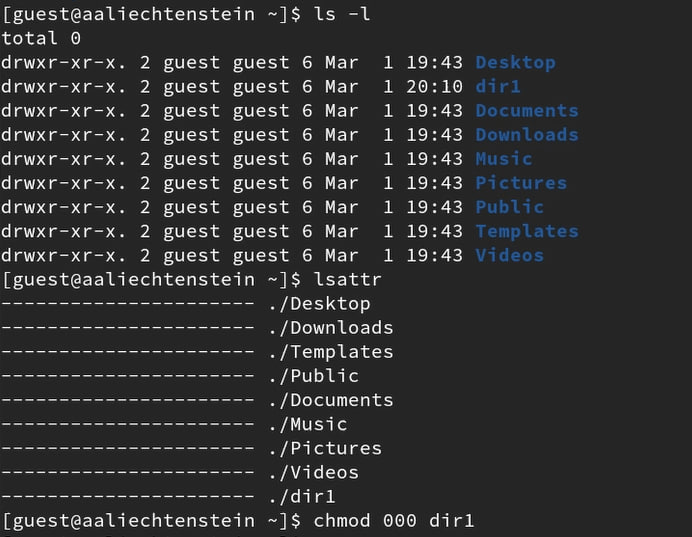

команды ls -l, lsattr и chmod

Попытаемся создать в директории dir1 файл file1 командой echo “test” > /home/guest/dir1/file1. Был получен отказ в выполнение операции по причине того, что мы сняли все атрибуты командой dir1.

Использование команды echo “test” > /home/guest/dir1/file1. (рис. [-@fig:007])

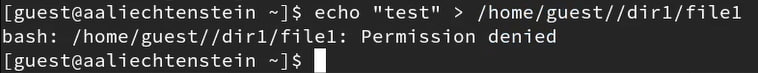

команда echo “test” > /home/guest/dir1/file1

# Выводы

В процессе выполнения данной лабораторной работы были успешно приобретены практические навыки работы в консоли с атрибутами файлов, закрепление теоретических основ дискреционного разграничения доступа в современных системах с открытым кодом на базе ОС Linuх.